# Loading and preprocessing the data

## Loading and preprocessing the data

```r
data <- read.table(unz("activity.zip", "activity.csv"), header=T, sep=",")
```

## What is mean total number of steps taken per day?

####1) Make a histogram of the total number of steps taken each day Here I've created “totalsData” which sums up the activity data by day, creating step count totals for each. I then subset that dataset to just the step totals.

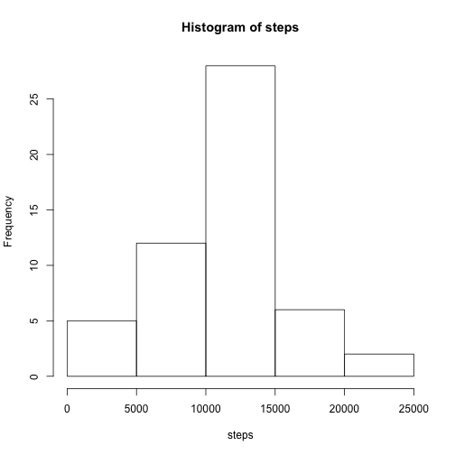

```r
totalsData = aggregate(steps ~ date, data=data, sum)
steps <- totalsData$steps
hist(steps)
```

####2) Calculate and report the mean and median total number of steps taken per day

```r
mean(steps)
```

```
## [1] 10766
```

```r
median(steps)
```

```
## [1] 10765
```

## What is the average daily activity pattern?

####1) Make a time series plot (i.e. type = “l”) of the 5-minute interval (x-axis) and the average number of steps taken, averaged across all days (y-axis)

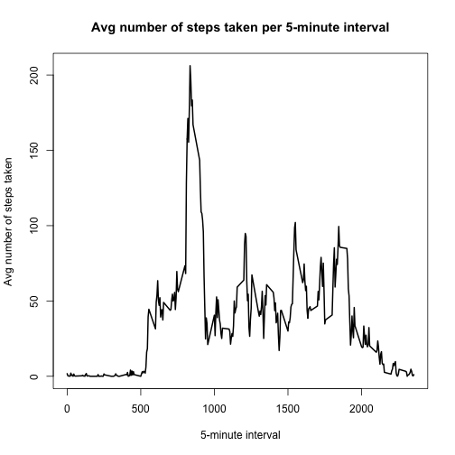

```r
totalsDataByInterval <- aggregate(steps ~ interval, data=data, mean)
plot(totalsDataByInterval$interval, totalsDataByInterval$steps, type="l", xlab= "5-minute interval", ylab= "Avg number of steps taken", main="Avg number of steps taken per 5-minute interval", lwd=2)
```

####2) Which 5-minute interval, on average across all the days in the dataset, contains the maximum number of steps?

```r
maxStepInterval <- totalsDataByInterval[which.max(totalsDataByInterval$steps),]$interval
maxStepInterval
```

```
## [1] 835
```

## Imputing missing values

####1) Calculate and report the total number of missing values in the dataset (i.e. the total number of rows with NAs)

```r
sum(is.na(data))
```

```
## [1] 2304
```

####3) Create a new dataset that is equal to the original dataset but with the missing data filled in.

```r
library(Hmisc)
imputedData <- data
imputedData$steps <- with(imputedData, impute(steps, mean))
```

####4) Make a histogram of the total number of steps taken each day and Calculate and report the mean and median total number of steps taken per day. Do these values differ from the estimates from the first part of the assignment? What is the impact of imputing missing data on the estimates of the total daily number of steps?

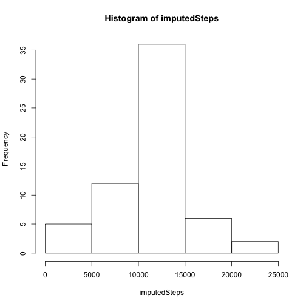

```r
imputedTotalsData = aggregate(steps ~ date, data=imputedData, sum)
imputedSteps <- imputedTotalsData$steps
hist(imputedSteps)
```

Now, let's compare how these new means compare with those from the first part of the assignment above when we did not sub for the NAs.

With no imputed values:

```r
mean(steps)
```

```
## [1] 10766
```

```r
median(steps)
```

```
## [1] 10765
```

With imputed values:

```r
mean(imputedSteps)
```

```
## [1] 10766
```

```r
median(imputedSteps)
```

```
## [1] 10766
```

## Are there differences in activity patterns between weekdays and weekends?

####1) Create a new factor variable in the dataset with two levels – “weekday” and “weekend” indicating whether a given date is a weekday or weekend day.

```r
imputedData$weekdays <- weekdays(as.Date(imputedData$date))
imputedData$weekdays <- ifelse(imputedData$weekdays %in% c("Saturday", "Sunday"), "weekend",
    "weekday")
library(plyr)
average <- ddply(imputedData, .(interval, weekdays), summarise, steps = mean(steps))
```

####2) Make a panel plot containing a time series plot (i.e. type = “l”) of the 5-minute interval (x-axis) and the average number of steps taken, averaged across all weekday days or weekend days (y-axis).

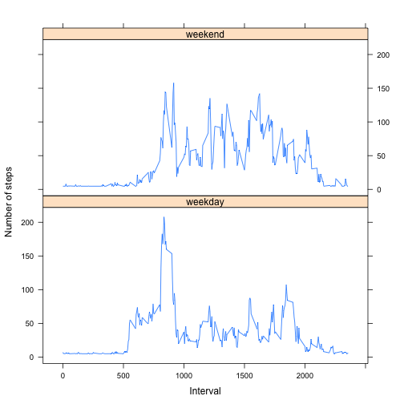

```r
library(lattice)
xyplot(steps ~ interval | weekdays, data = average, layout = c(1, 2), type = "l",
    xlab = "Interval", ylab = "Number of steps")
```